# Analysis Walkthrough

## Overview

This section documents the full analysis process—from data preparation through modeling.

For a summary of insights, visit the [Key Findings](https://calfresh-cfa-exercise.netlify.app/key_findings) page.  
For project context, visit the [About](https://calfresh-cfa-exercise.netlify.app/about) page.

## Application Walkthrough

Before analyzing the data, I walked through the [GetCalFresh.org](https://www.getcalfresh.org) application process myself. This helped clarify how each field is presented to applicants, what steps are required or optional, and where friction might arise.

Seeing the application from a user’s perspective provided critical context for interpreting the dataset — especially for process-related variables like document uploads, interview completion, and application duration.

### Key Takeaways

- **Multilingual support** is available early in the application (English, Spanish, Chinese, Vietnamese), with additional language preferences captured later.
- **The application is structured in stages**: household info → income → expenses → contact details → confirmation.
- **Applicants get real-time feedback** about possible eligibility and whether they might qualify for expedited processing.
- **Document uploads and interviews aren’t required at submission** — they can happen later, which means missing data doesn’t always signal ineligibility.
- **Toward the end**, applicants confirm contact information, set preferences (e.g., language, reminders), and indicate interview availability.

This walkthrough was useful for interpreting behavioral data in context — especially steps that are optional, delayed, or invisible in the dataset (like phone interviews completed outside the platform).

## About the Data

This dataset includes 2,046 CalFresh (SNAP) applications submitted through GetCalFresh.org in San Diego County. Each row represents one application and contains:

- Information reported by the applicant
- Activity tracked through the GetCalFresh platform
- Final approval outcome provided by the county

The dataset reflects the user-facing side of the process. It does not capture every factor a county worker might see (e.g., paper documents or offline interviews), but it provides a detailed view of what users did on the site and what happened afterward.

**Key Variables**

| Variable | Description | Notes |
| --- | --- | --- |
| `income` | Household income in the last 30 days | Slightly randomized for privacy |
| `household_size` | Number of people applying | Used to determine income thresholds |
| `docs_with_app` | Documents uploaded with the application | Optional at time of submission |
| `docs_after_app` | Documents uploaded after submission | Often submitted after the interview |
| `had_interview` | Applicant’s self-report of completing the interview | Based on SMS follow-up; may be missing |
| `completion_time_mins` | Time taken to complete the application | May include pauses or returns |
| `stable_housing` | Whether applicant rents/owns their sleeping location | Proxy for housing stability |
| `under18_n`, `over_59_n` | Children or older adults in the household | May influence prioritization or eligibility |
| `zip` | Applicant ZIP code | May reflect local conditions or access issues |
| `approved` | Final approval outcome | Provided by the county |

Contextual Notes:

- **Interview completion** (`had_interview`) comes from an SMS response. Missing values do not confirm whether an interview occurred — only that no reply was recorded.
- **Document fields** only include uploads through GetCalFresh. Submissions made by mail, fax, or in person are not tracked here.
- **Approval decisions** come from county records and represent real outcomes.

Understanding what’s captured — and what’s missing — helped guide how I handled missingness and interpreted variables.

## Exploratory Data Analysis

Before modeling, I conducted an exploratory analysis to:

- Understand the distribution and structure of each variable
- Identify missingness and data quality issues
- Spot early signals related to approval
- Prepare features for interpretability and modeling

### Codebook Summary

I created a structured codebook using a function from my own `databookR` package. It describes each variable, its type, missingness, and key statistics — and forms the foundation for all further steps.

```r
# Add descriptions to variables
var_desc <- list(
  app_id               = "Unique identifier for each application",
  completion_time_mins = "Time taken to complete the application, in minutes",
  household_size       = "Number of people applying for CalFresh in the household",
  income               = "Total household income in the last 30 days (randomized slightly for privacy)",
  docs_with_app        = "Count of verification documents uploaded with the initial application",
  docs_after_app       = "Count of verification documents uploaded after application (via Later Docs)",
  under18_n            = "Number of children age 17 or younger included in the application",
  over_59_n            = "Number of adults age 60 or older included in the application",
  stable_housing       = "TRUE if applicant rents or owns the place they sleep; FALSE otherwise",
  had_interview        = "TRUE if applicant reported completing the required interview; may be missing",
  zip                  = "ZIP code where the applicant lives or stays",
  approved             = "TRUE if the application was approved for CalFresh by the county"
)

# Generate databook
databookR::databook(exercise_data, var_descriptions = var_desc)
```

| Variable Name | Variable Description | Variable Type | Number of Unique Values | Percentage Missing | Statistics |
| --- | --- | --- | --- | --- | --- |
| app_id | Unique identifier for each application | numeric | 2046 | 0.0% | Min: 1.0 Avg: 38866.9 Median: 38066.5 Max: 110550.0 SD: 25305.4 |
| completion_time_mins | Time taken to complete the application, in minutes | numeric | 2046 | 0.0% | Min: 2.3 Avg: 21.4 Median: 10.4 Max: 8551.8 SD: 195.7 |
| household_size | Number of people applying for CalFresh in the household | numeric | 10 | 0.2% | Min: 1.0 Avg: 1.8 Median: 1.0 Max: 12.0 SD: 1.3 |
| income | Total household income in the last 30 days (randomized slightly for privacy) | numeric | 888 | 0.0% | Min: 0.0 Avg: 936.0 Median: 270.0 Max: 9779.0 SD: 1228.9 |
| docs_with_app | Count of verification documents uploaded with the initial application | numeric | 19 | 0.0% | Min: 0.0 Avg: 1.3 Median: 0.0 Max: 25.0 SD: 2.2 |
| docs_after_app | Count of verification documents uploaded after application (via Later Docs) | numeric | 20 | 0.0% | Min: 0.0 Avg: 0.8 Median: 0.0 Max: 29.0 SD: 2.1 |
| under18_n | Number of children age 17 or younger included in the application | numeric | 7 | 0.2% | Min: 0.0 Avg: 0.5 Median: 0.0 Max: 6.0 SD: 1.0 |
| over_59_n | Number of adults age 60 or older included in the application | numeric | 3 | 0.2% | Min: 0.0 Avg: 0.1 Median: 0.0 Max: 2.0 SD: 0.3 |
| stable_housing | TRUE if applicant rents or owns the place they sleep; FALSE otherwise | logical | 2 | 0.0% | TRUE: 1186 (58.0%) FALSE: 860 (42.0%) |
| had_interview | TRUE if applicant reported completing the required interview; may be missing | logical | 2 | 49.7% | TRUE: 595 (57.8%) FALSE: 434 (42.2%) |
| zip | ZIP code where the applicant lives or stays | factor | 28 | 0.0% | Top 5 Categories: 92105 = 162 (7.9%) 92114 = 157 (7.7%) 92113 = 155 (7.6%) 92115 = 133 (6.5%) 92154 = 128 (6.3%) |
| approved | TRUE if the application was approved for CalFresh by the county | logical | 2 | 0.0% | TRUE: 1148 (56.1%) FALSE: 898 (43.9%) |

Notable Patterns:

This codebook gave me a clear view of how people move through the process. It highlighted variables with missing or unusual values, flagged behaviors worth looking into (like how few applicants upload documents or report completing interviews), and pointed to patterns that might be important for understanding who gets approved.

### Missingness

To assess data quality, I visualized missingness across all variables using `vis_miss()`.

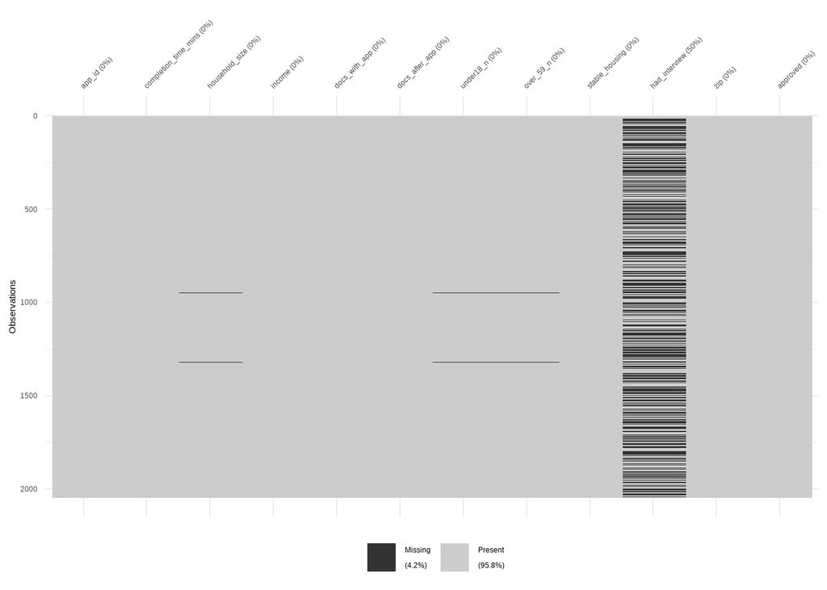

```r
vis_miss(exercise_data)
```

Only had_interview has meaningful missing data (~50%). All other fields are complete or nearly complete. This missingness is expected — the interview variable comes from a follow-up SMS survey, and not all applicants respond.

### Distribution of Key Variables

I next reviewed distributions of numeric variables to check for skew, outliers, and interpretability issues.

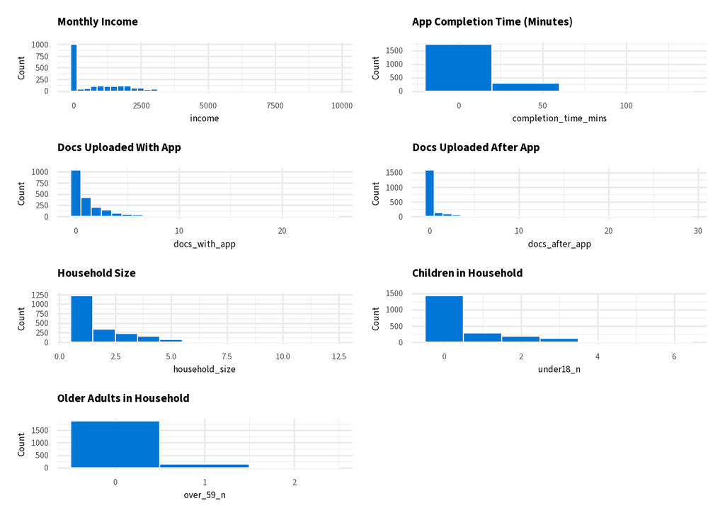

```r
# Custom binwidths
binwidths <- list(
  income = 250,
  completion_time_mins = 40,
  docs_with_app = 1,
  docs_after_app = 1,
  household_size = 1,
  under18_n = 1,
  over_59_n = 1
)

# Generate all plots
wrap_plots(
  fnc_plot_var("income", "Monthly Income"),
  fnc_plot_var("completion_time_mins", "App Completion Time (Minutes)", max_x = 120),
  fnc_plot_var("docs_with_app", "Docs Uploaded With App"),
  fnc_plot_var("docs_after_app", "Docs Uploaded After App"),
  fnc_plot_var("household_size", "Household Size"),
  fnc_plot_var("under18_n", "Children in Household"),
  fnc_plot_var("over_59_n", "Older Adults in Household"),
  ncol = 2
)
```

Observations:

- **Income** is heavily right-skewed. Most applicants report less than $500/month.
- **Completion time** clusters below 20 minutes. A few outliers extend far beyond that range.
- **Document uploads:** The majority of applicants upload no documents at all, either before or after applying.
- **Household size:** Most applicants apply alone or with one other person.
- **Children and older adults:** Most applications list zero dependents under 18 or over 59.

These patterns suggest that most applicants are low-income, likely applying alone, and often do not upload documents upfront — all of which could influence approval outcomes.

### Correlation and Redundancy Check

Before modeling, I examined relationships among predictors to identify potential multicollinearity or redundancy. This ensures that coefficients remain stable and interpretable.

**Method 1: Correlation Matrix**

I computed pairwise correlations among numeric variables:

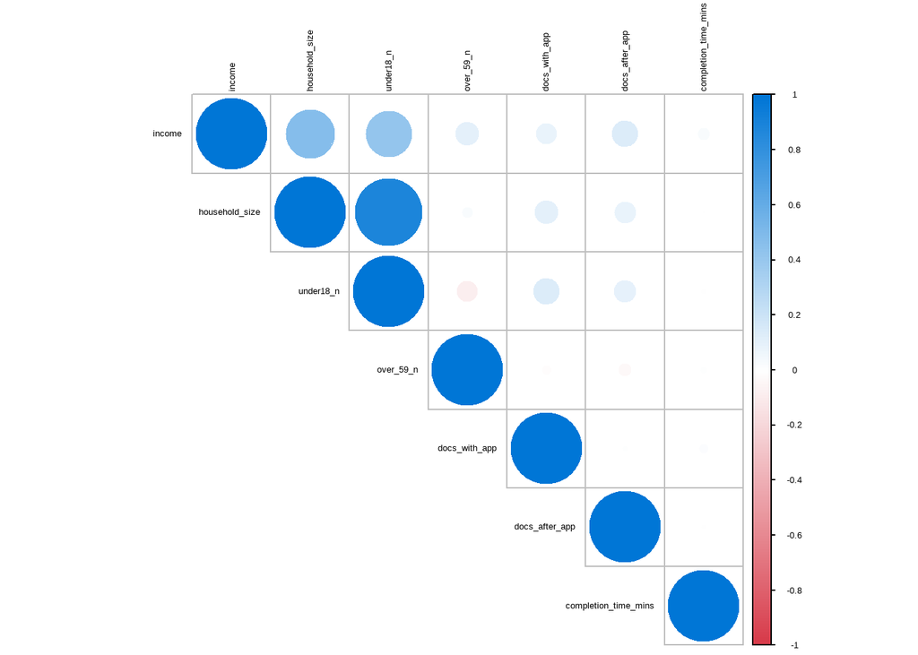

```r
# Select numeric predictors
num_vars <- exercise_data |>
  select(income, household_size, under18_n, over_59_n,
         docs_with_app, docs_after_app, completion_time_mins)

# Compute correlations
cor_matrix <- cor(num_vars, use = "complete.obs")

# Visualize
corrplot(cor_matrix, method = "circle", type = "upper",
         tl.cex = 0.8, tl.col = "black",
         col = colorRampPalette(c(cfa_colors$red, "white", cfa_colors$blue))(200))
```

**Method 2: Variance Inflation Factor (VIF)**

I fit a preliminary logistic regression model to compute VIFs:

```r
# Quick VIF check with basic logistic model
vif_model <- glm(
  approved ~ income + household_size + under18_n + over_59_n +
    docs_with_app + docs_after_app + completion_time_mins +
    stable_housing + had_interview,
  data = exercise_data,
  family = binomial()
)

car::vif(vif_model)
```

```
              income       household_size            under18_n
            1.570242             4.949500             4.810768
           over_59_n        docs_with_app       docs_after_app
            1.082801             1.071075             1.094315
completion_time_mins       stable_housing        had_interview
            1.012481             1.241863             1.105751
```

- `household_size` (4.95) and `under18_n` (4.81) show moderate multicollinearity — expected due to their conceptual overlap.
- All other variables have VIFs below 2.

Both variables `household_size` and `under18_n`, will likely be retained. While correlated, they reflect different eligibility factors: household size affects income limits, while the presence of children may affect processing or priority.

### Approval Rates by Key Variables

To understand where in the process outcomes start to diverge, I looked at approval rates across key variables. This helped identify patterns worth modeling and showed possible intervention points.

### Interview Completion

```r
fnc_approval_summary(exercise_data, had_interview)
```

| Group | N | Approval Rate (%) |
| --- | --- | --- |
| FALSE | 434 | 50.0 |
| TRUE | 595 | 72.1 |
| NA | 1,017 | 49.4 |

- Applicants who **reported completing the interview** had higher approval rates than those who did not or whose response was missing.
- This reinforces the interview as a critical point of potential drop-off.
- Missing responses likely indicate no follow-up engagement — not necessarily ineligibility.

### Document Submission Group

I grouped applicants by when (or whether) they submitted documents:

```r
# Add a doc_group variable
exercise_data <- exercise_data |>
  mutate(
    doc_group = case_when(
        docs_with_app > 0 & docs_after_app == 0 ~ "With App Only",
        docs_with_app == 0 & docs_after_app > 0 ~ "After App Only",
        docs_with_app > 0 & docs_after_app > 0 ~ "With + After",
        docs_with_app == 0 & docs_after_app == 0 ~ "No Docs"
        ) |>
      factor(levels = c("With App Only", "After App Only", "With + After", "No Docs"))
      )
fnc_approval_summary(exercise_data, doc_group)
```

| Group | N | Approval Rate (%) |
| --- | --- | --- |
| With App Only | 797 | 65.0 |
| After App Only | 248 | 57.3 |
| With + After | 213 | 65.7 |
| No Docs | 788 | 44.2 |

- Approval was highest among applicants who **submitted documents with their initial application.**
- Applicants who submitted documents only after applying had moderately lower rates.
- The **lowest approval rate** (~44%) was among those who submitted nothing online.

This suggests that early document submission may signal follow-through — or speed up processing.

### Housing Stability

```r
fnc_approval_summary(exercise_data, stable_housing)
```

| Group | N | Approval Rate (%) |
| --- | --- | --- |
| FALSE | 860 | 64.4 |
| TRUE | 1,186 | 50.1 |

- Applicants reporting **unstable housing had higher approval rates.**
- This may reflect prioritized eligibility for those experiencing housing instability.
- Housing instability may increase likelihood of approval due to expedited or simplified eligibility pathways.

### Household Size (Binned)

I binned household size for interpretability:

```r
# Add bins
exercise_data <- exercise_data |>
  mutate(household_size_bin = cut(household_size, breaks = c(0,1,2,3,5,10)))

fnc_approval_summary(exercise_data, household_size_bin)
```

| Group | N | Approval Rate (%) |
| --- | --- | --- |
| (0,1] | 1,223 | 61.7 |
| (1,2] | 334 | 52.1 |
| (2,3] | 227 | 45.4 |
| (3,5] | 228 | 46.1 |
| (5,10] | 29 | 27.6 |
| NA | 5 | 60.0 |

- 1–2 person households had the highest approval rates.
- Larger households saw lower approval rates.
- This may be due to stricter income thresholds at higher household sizes — or more complexity in verifying eligibility.

### ZIP Code Variation

ZIP code can reflect structural factors that influence access: geography, internet connectivity, support, and even worker caseloads. While it’s not causal, it helps show system-level variation.

I assessed variation in approval rates by ZIP code, filtering out ZIPs with fewer than 10 applications:

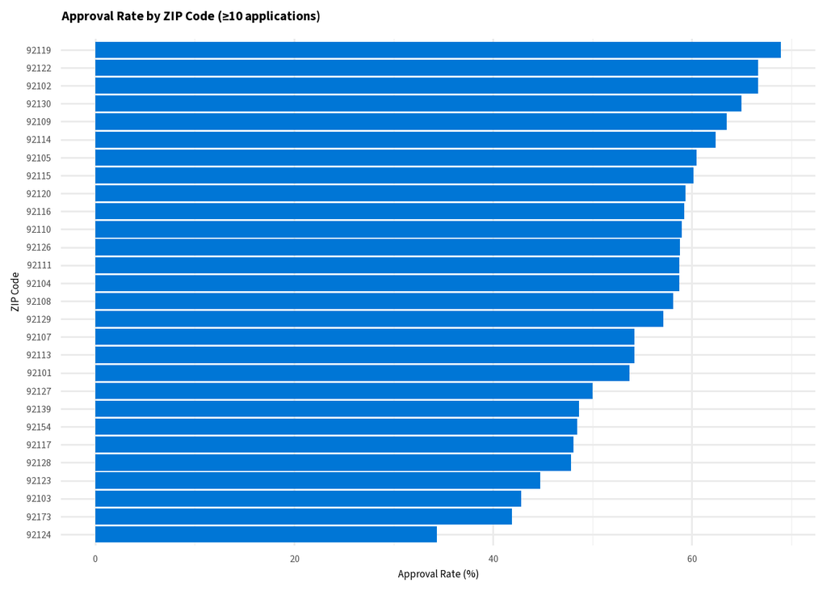

```r
# Aggregate by ZIP (filter out sparse ZIPs)
zip_summary <- exercise_data |>
  group_by(zip) |>
  summarize(
    n = n(),
    approval_rate = mean(approved, na.rm = TRUE)
  ) |>
  filter(n >= 10)

# Bar chart
ggplot(zip_summary, aes(x = fct_reorder(zip, approval_rate),
                        y = approval_rate * 100)) +
  geom_col(fill = cfa_colors$blue) +
  coord_flip() +
  labs(
    title = "Approval Rate by ZIP Code (≥10 applications)",
    x = "ZIP Code",
    y = "Approval Rate (%)"
  ) +
  fnc_theme_cfa()
```

Notes:

- Approval rates vary from ~34% to ~69% across ZIP codes.
- This range is large enough to suggest systematic differences, not just noise.
- High- and low-performing ZIPs each have reasonable sample sizes, supporting this concern.

### Statistical Test: Is ZIP Predictive of Approval?

To formally test whether ZIP code is predictive of approval, I ran a chi-squared test:

```r
zip_test <- exercise_data |>
  filter(!is.na(approved), !is.na(zip)) |>
  count(zip, approved) |>
  pivot_wider(names_from = approved, values_from = n, values_fill = 0) |>
  column_to_rownames("zip") |>
  as.matrix() |>
  chisq.test()

zip_test
```

```
    Pearson's Chi-squared test

data:  as.matrix(column_to_rownames(pivot_wider(count(filter(exercise_data,     !is.na(approved), !is.na(zip)), zip, approved), names_from = approved,     values_from = n, values_fill = 0), "zip"))
X-squared = 43.85, df = 27, p-value = 0.02143
```

Interpretation:

- The chi-squared test was **statistically significant** (p < 0.05).
- We reject the null hypothesis that approval rates are independent of ZIP code.
- Even without socioeconomic indicators, ZIP appears to meaningfully stratify outcomes.

### Preparation for Modeling

Before fitting a model, I created new variables and adjusted a few existing ones to improve interpretability. These changes were grounded in earlier exploratory analysis and CalFresh eligibility rules.

The goal was to make model coefficients easier to interpret and ensure alignment with how eligibility and case processing work in practice.

**Income**

```r
exercise_data <- exercise_data |>
  mutate(income_500 = income / 500)
```

- Scaled income in $500 units to make coefficients easier to interpret.
- A log-odds change now reflects the effect of each additional ~$500 in monthly income, not each dollar.

**Application Completion Time**

```r
exercise_data <- exercise_data |>
  mutate(
    completion_time_capped = if_else(completion_time_mins > 180, 180, completion_time_mins),
    long_app = completion_time_mins > 60
  )
```

- Capped extreme values above 180 minutes to reduce the of outliers.
- Flagged apps that took more than one hour (long_app) to explore whether interruptions or complexity affect outcomes.

**Interview Completion (Self-Reported)**

```r
exercise_data <- exercise_data |>
  mutate(interview_completed = case_when(
    had_interview == TRUE ~ "Completed",
    TRUE ~ "Not confirmed"
  ) |> factor(levels = c("Not confirmed", "Completed")))
```

- Re-coded had_interview into a 2-category factor:
  - “Completed” = applicant said they had the interview
  - “Not confirmed” = didn’t respond or said no
- This avoids misinterpreting missing data as a definitive “no”

## Income Eligibility

To better understand who should be approved under CalFresh rules, I used the official [income eligibility thresholds](https://dpss.lacounty.gov/en/food/calfresh/gross-income.html) based on household size.

These limits reflect the 200% Federal Poverty Level under California’s Broad-Based Categorical Eligibility (BBCE) policy.

This allows us to distinguish:

- Applicants who likely met income-based eligibility
- Applicants who may have been denied despite being income-eligible
- The extent to which approval decisions align with income thresholds

```r
# Create eligibility table based on the table here:
# https://dpss.lacounty.gov/en/food/calfresh/gross-income.html
eligibility_table <- tibble::tibble(
  household_size = 1:8,
  max_gross_income = c(2510, 3408, 4304, 5200, 6098, 6994, 7890, 8788)
)

# Join with application data
exercise_data <- exercise_data |>
  left_join(eligibility_table, by = "household_size") |>
  mutate(
    income_eligible = income <= max_gross_income
  )

# Approval summary by income eligibility
approval_summary <- exercise_data |>
  group_by(income_eligible) |>
  summarize(
    n = n(),
    approval_rate = mean(approved, na.rm = TRUE),
    approved_over_income = sum(approved & !income_eligible, na.rm = TRUE),
    .groups = "drop"
  ) |>
  mutate(
    approval_rate = round(approval_rate * 100, 1)
  )

# Highlight minimum approval rate
min_rate <- min(approval_summary$approval_rate, na.rm = TRUE)

approval_summary |>
  gt::gt() |>
  gt::cols_label(
    income_eligible = "Income-Eligible?",
    n = "N",
    approval_rate = "Approval Rate (%)",
    approved_over_income = "Approved Despite High Income"
  ) |>
  gt::fmt_number(columns = c(n, approved_over_income), decimals = 0) |>
  fnc_style_gt_table()
```

| Income-Eligible? | N | Approval Rate (%) | Approved Despite High Income |
| --- | --- | --- | --- |
| FALSE | 43 | 9.3 | 4 |
| TRUE | 1,997 | 57.1 | 0 |
| NA | 6 | 50.0 | 0 |

Takeaways:

- Most applicants appear income-eligible.
- A small number were approved despite exceeding income thresholds — potentially due to exceptions, data entry errors, or income verification.
- Nearly half of income-eligible applicants were not approved, pointing to process barriers like missed interviews or incomplete documentation.

This flag helps contextualize approval decisions in the model, especially when eligible applicants are denied.

## Logistic Regression

To identify factors most strongly associated with CalFresh approval, I fit a logistic regression model. This model estimates the likelihood of approval based on eligibility-related variables and applicant actions observed through the application process.

### Variable Selection Rationale

I included variables based on:

- Program relevance (e.g., income, household size)
- User experience (e.g., document upload, interview)
- Results from earlier exploratory analysis

The final model uses:

- Scaled income: `income_500`
- Household composition: `household_size`, `under18_n`, `over_59_n`
- Document submission: `docs_with_app`, `docs_after_app`
- Time spent applying: `completion_time_capped`
- Housing stability: `stable_housing`
- Interview completion: `interview_completed` (re-coded)

### Model Specification

```r
approval_model <- glm(
  approved ~ income_500 + household_size + under18_n + over_59_n +
    docs_with_app + docs_after_app + completion_time_capped +
    stable_housing + interview_completed,
  data = exercise_data,
  family = binomial()
)

summary(approval_model)
```

```
Call:
glm(formula = approved ~ income_500 + household_size + under18_n +
    over_59_n + docs_with_app + docs_after_app + completion_time_capped +
    stable_housing + interview_completed, family = binomial(),
    data = exercise_data)

Coefficients:
                              Estimate Std. Error z value Pr(>|z|)
(Intercept)                   0.628432   0.131272   4.787 1.69e-06 ***
income_500                   -0.412618   0.029816 -13.839  < 2e-16 ***
household_size               -0.125768   0.088893  -1.415  0.15712
under18_n                     0.300545   0.117048   2.568  0.01024 *
over_59_n                     0.121020   0.155961   0.776  0.43777
docs_with_app                 0.116576   0.025326   4.603 4.16e-06 ***
docs_after_app                0.075872   0.027076   2.802  0.00507 **
completion_time_capped       -0.001958   0.002632  -0.744  0.45674
stable_housingTRUE           -0.086942   0.112313  -0.774  0.43887
interview_completedCompleted  1.098309   0.118276   9.286  < 2e-16 ***
---
Signif. codes:  0 '***' 0.001 '**' 0.01 '*' 0.05 '.' 0.1 ' ' 1

(Dispersion parameter for binomial family taken to be 1)

    Null deviance: 2800.1  on 2041  degrees of freedom
Residual deviance: 2373.5  on 2032  degrees of freedom
  (4 observations deleted due to missingness)
AIC: 2393.5

Number of Fisher Scoring iterations: 4
```

Interpretation:

- **Interview completed** had the strongest association with approval.
- **Higher income** reduced the odds of approval, as expected.
- **Document uploads** (both with and after application) were positively associated with approval.
- **Each additional child** was associated with higher approval odds.
- **Other variables** (e.g., housing stability, household size, older adults, app time) were not significant once the above were accounted for.

### Odds Ratios and Confidence Intervals

```r
model_results <- broom::tidy(approval_model, exponentiate = TRUE, conf.int = TRUE)

model_results |>
  select(term, estimate, conf.low, conf.high, p.value) |>
  mutate(across(where(is.numeric), round, 2)) |>
  gt::gt() |>
  gt::cols_label(
    term = "Variable",
    estimate = "Odds Ratio",
    conf.low = "95% CI (Low)",
    conf.high = "95% CI (High)",
    p.value = "P-Value"
  ) |>
  fnc_style_gt_table()
```

| Variable | Odds Ratio | 95% CI (Low) | 95% CI (High) | P-Value |
| --- | --- | --- | --- | --- |
| (Intercept) | 1.87 | 1.45 | 2.43 | 0.00 |
| income_500 | 0.66 | 0.62 | 0.70 | 0.00 |
| household_size | 0.88 | 0.74 | 1.05 | 0.16 |
| under18_n | 1.35 | 1.07 | 1.70 | 0.01 |
| over_59_n | 1.13 | 0.83 | 1.53 | 0.44 |
| docs_with_app | 1.12 | 1.07 | 1.18 | 0.00 |
| docs_after_app | 1.08 | 1.02 | 1.14 | 0.01 |
| completion_time_capped | 1.00 | 0.99 | 1.00 | 0.46 |
| stable_housingTRUE | 0.92 | 0.74 | 1.14 | 0.44 |
| interview_completedCompleted | 3.00 | 2.38 | 3.79 | 0.00 |

- An odds ratio > 1 means the variable is associated with a higher chance of approval
- An odds ratio < 1 means a lower chance

Interpretation:

- Interview completed: ~3x higher odds of approval
- Each $500 in income: ~34% lower odds
- Each document uploaded with the application: ~12% higher odds
- Each child (under 18): ~35% higher odds

These results reinforce earlier descriptive findings — but also show that certain variables (like app duration or housing status) have little added explanatory value once core factors are controlled for.

## Diagnostics

After fitting the logistic regression, I ran several checks to evaluate how well the model fits the data and whether the results are trustworthy. These diagnostics focus on:

- How much variation the model explains
- Whether predicted probabilities align with actual outcomes
- How well the model distinguishes approved vs. denied applications

**1. McFadden’s Psuedo R²**

Definition: A measure of how much better the model fits the data compared to a model with no predictors (just an intercept).

```r
# Pseudo R-squared
pscl::pR2(approval_model)
```

```
fitting null model for pseudo-r2
```

```
          llh       llhNull            G2      McFadden          r2ML
-1186.7634616 -1400.0644571   426.6019909     0.1523508     0.1885348
         r2CU
    0.2526548
```

The pseudo R² was around **0.15**, which indicates a moderate effect size. That’s typical in behavioral data, where many influencing factors aren’t captured in the dataset.

**2. Hosmer–Lemeshow Goodness-of-Fit Test**

This test checks whether the model’s predicted probabilities align with the actual outcomes. It groups observations into deciles by predicted probability, then compares predicted vs. actual approval rates in each group.

```r
hoslem.test(approval_model$y, fitted(approval_model))
```

```
    Hosmer and Lemeshow goodness of fit (GOF) test

data:  approval_model$y, fitted(approval_model)
X-squared = 9.0452, df = 8, p-value = 0.3385
```

Our p-value is 0.34, which is not staistically significant. That’s good — it means there’s no evidence of poor fit. The model’s predictions are consistent with observed data.

**3. ROC Curve and AUC (Area Under the Curve)**

AUC summarizes how well the model distinguishes between approved and denied applicants.

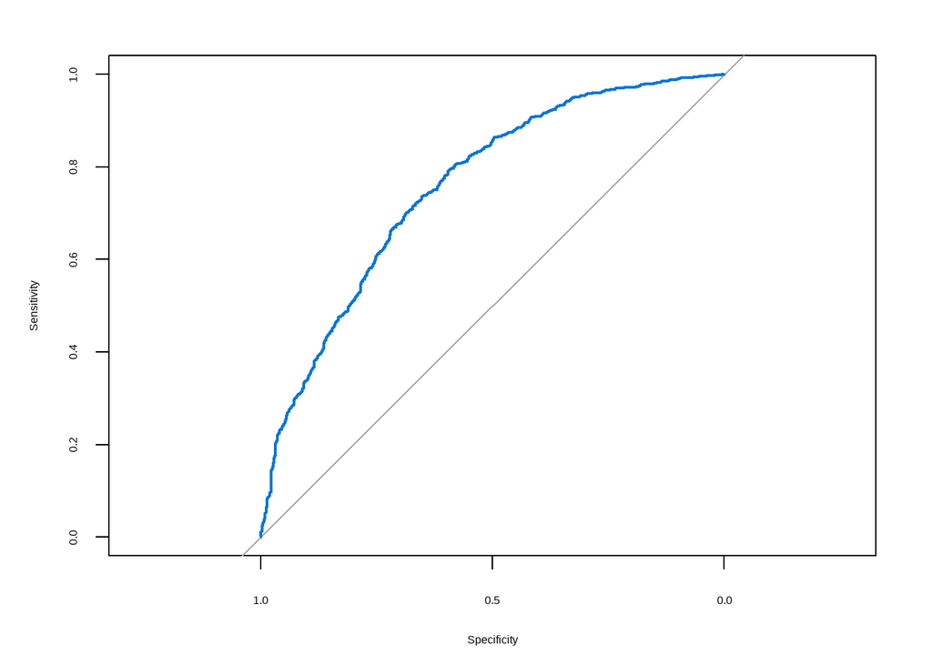

```r
model_data <- model.frame(approval_model)
actual <- model_data$approved
predicted <- fitted(approval_model)

roc_obj <- roc(actual, predicted)
plot(roc_obj, col = cfa_colors$blue, lwd = 2)
```

```r
pROC::auc(roc_obj)
```

```
Area under the curve: 0.7563
```

Interpretation:

- AUC = 0.76 means the model assigns a higher predicted probability to an approved case than a denied one 76% of the time.
- That’s considered good performance for a logistic model using only observable application behaviors.

Together, these diagnostics show that the model is well-calibrated, explains meaningful variation, and performs reliably — even with known limitations in the dataset.

**4. Train/Test Split**

To evaluate how well the model generalizes, I randomly split the data into:

- 80% training set (used to fit the model)
- 20% test set (used to evaluate performance on unseen data)

The model was re-fit on the training set, and predicted approval probabilities were generated for the test set. AUC was then calculated on these out-of-sample predictions.

```r
set.seed(42)

# Split the data
train_idx <- sample(seq_len(nrow(exercise_data)), size = 0.8 * nrow(exercise_data))
train_data <- exercise_data[train_idx, ]
test_data  <- exercise_data[-train_idx, ]

# Refit model on training set
approval_model <- glm(
  approved ~ income_500 + household_size + under18_n + over_59_n +
    docs_with_app + docs_after_app + completion_time_capped +
    stable_housing + interview_completed,
  data = train_data,
  family = binomial()
)

# Predict on test set
test_data <- test_data |>
  mutate(predicted_prob = predict(approval_model, newdata = test_data, type = "response"))

# AUC on test data
roc_test <- roc(test_data$approved, test_data$predicted_prob)
auc(roc_test)
```

```
Area under the curve: 0.7465
```

## Predicted Probabilities

The logistic regression model produces a predicted probability of approval for each application. These values reflect how likely someone was to be approved, based on their reported information and process steps.

Looking at predicted probabilities helps identify:

- Who was almost certain to be approved or denied
- Who was in a gray zone, where approval was uncertain
- Where small changes — like completing an interview — might make a difference

### Distribution of Predicted Probabilities

Add predicted probabilities to the data:

```r
model_data <- model.frame(approval_model) |>
  mutate(predicted_prob = predict(approval_model, type = "response"))
```

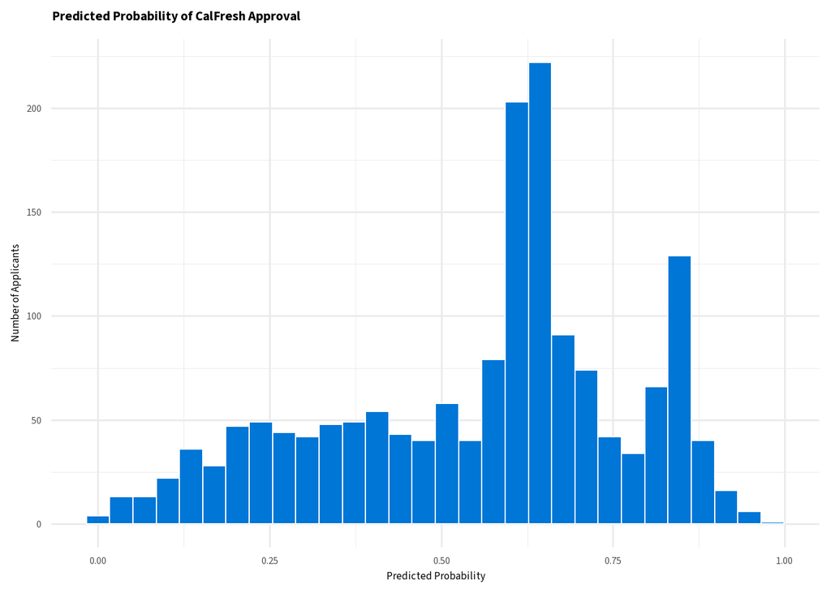

```r
ggplot(model_data, aes(x = predicted_prob)) +
  geom_histogram(fill = cfa_colors$blue, color = "white", bins = 30) +
  labs(
    title = "Predicted Probability of CalFresh Approval",
    x = "Predicted Probability",
    y = "Number of Applicants"
  ) +
  fnc_theme_cfa()
```

Interpretation:

- Most applicants had predicted probabilities between 0.3 and 0.8, with two peaks:
  - A major peak centered around 0.65
  - A secondary peak around 0.8
- There are fewer applicants with very low (near 0) or very high (near 1) probabilities, which makes sense — no single factor fully determines approval.

The distribution suggests real variability in approval likelihood — and that many applicants fall into a moderate range of uncertainty, not extremes.

### Example: Interview Completion

To show how much one variable matters, I compared average predicted probabilities by interview status:

```r
model_data |>
  group_by(interview_completed) |>
  summarize(
    mean_pred_prob = round(mean(predicted_prob), 2),
    n = n()
  ) |>
  gt::gt() |>
  gt::cols_label(
    interview_completed = "Interview Completed?",
    mean_pred_prob = "Avg. Predicted Probability",
    n = "N"
  ) |>
  gt::fmt_number(columns = n, decimals = 0) |>
  fnc_style_gt_table()
```

| Interview Completed? | Avg. Predicted Probability | N |
| --- | --- | --- |
| Not confirmed | 0.49 | 1,161 |
| Completed | 0.72 | 472 |

Interpretation:

- Applicants who completed the interview had a **72%** average predicted chance of approval
- Those who did not (or did not confirm) had just a **50%** chance

This 22-point gap is one of the clearest signals in the model — and points to a place where better support could help.

### Segmenting Applicants

To better understand who might benefit from support, I grouped applicants by predicted approval probability. This helps identify:

- Who is most likely to be approved or denied
- Who falls into a gray area, where outcomes are harder to predict

Define confidence bands:

```r
model_data <- model_data |>
  mutate(prob_band = case_when(
    predicted_prob < 0.4 ~ "Low (<40%)",
    predicted_prob >= 0.4 & predicted_prob < 0.6 ~ "Moderate (40–59%)",
    predicted_prob >= 0.6 & predicted_prob < 0.8 ~ "High (60–79%)",
    predicted_prob >= 0.8 ~ "Very High (80%+)"
  ) |> factor(levels = c("Low (<40%)", "Moderate (40–59%)", "High (60–79%)", "Very High (80%+)")))
```

Summary by band:

```r
model_data |>
  group_by(prob_band) |>
  summarize(
    n = n(),
    actual_approval_rate = round(mean(approved, na.rm = TRUE) * 100, 1)
  ) |>
  gt::gt() |>
  gt::cols_label(
    prob_band = "Predicted Probability Band",
    n = "N",
    actual_approval_rate = "Observed Approval Rate (%)"
  ) |>
  fnc_style_gt_table()
```

| Predicted Probability Band | N | Observed Approval Rate (%) |
| --- | --- | --- |
| Low (<40%) | 408 | 23.0 |
| Moderate (40–59%) | 316 | 48.4 |
| High (60–79%) | 654 | 67.9 |
| Very High (80%+) | 255 | 85.9 |

Interpretation:

- **Very High (80%+):** Most of these applicants were approved — minimal intervention needed.
- **High (60–79%):** Still strong performance, but some denials suggest small process gaps (e.g., missing docs).
- **Moderate (40–59%):** This is the gray zone — almost half are denied. This group could benefit most from added support.
- **Low (<40%):** Most were denied, but if any were income-eligible, this may indicate missed opportunities.

### Gray Zone

To learn more about applicants in the 40–59% predicted range, I created a summary of their characteristics.

```r
# Get only the rows used in the model
used_rows <- as.numeric(rownames(model.frame(approval_model)))

# Add predicted probabilities + other variables used in analysis
model_data <- exercise_data[used_rows, ] |>
  mutate(
    predicted_prob = predict(approval_model, type = "response")
  )

gray_zone <- model_data |>
  filter(predicted_prob >= 0.4, predicted_prob < 0.6)

gray_zone_summary <- gray_zone |>
  summarize(
    n = n(),
    approval_rate = round(mean(approved, na.rm = TRUE) * 100, 1),
    pct_income_eligible = round(mean(income_eligible, na.rm = TRUE) * 100, 1),
    pct_docs_with_app = round(mean(docs_with_app > 0) * 100, 1),
    pct_docs_after_app = round(mean(docs_after_app > 0) * 100, 1),
    pct_completed_interview = round(mean(interview_completed == "Completed") * 100, 1)
  )

gray_zone_summary |>
  pivot_longer(everything()) |>
  gt::gt() |>
  gt::cols_label(
    name = "Metric",
    value = "%"
  ) |>
  gt::fmt_number(columns = value, decimals = 1) |>
  fnc_style_gt_table()
```

| Metric | % |
| --- | --- |
| n | 316.0 |
| approval_rate | 50.6 |
| pct_income_eligible | 98.4 |
| pct_docs_with_app | 46.5 |
| pct_docs_after_app | 24.4 |
| pct_completed_interview | 31.3 |

What stands out:

This group represents a major opportunity: they’re likely eligible, but many didn’t complete the full process. Small nudges or reminders could meaningfully increase approvals.

## Conclusion

This analysis examined patterns in CalFresh (SNAP) application outcomes among GetCalFresh.org users in San Diego County. Several process-related factors were strongly associated with whether an applicant was approved.

**Key Findings:**

- **Interview completion was the most predictive factor:** Applicants who reported completing the interview were nearly three times more likely to be approved.
- **Document uploads mattered:** Uploading verification documents — especially with the initial application — was associated with higher approval rates.
- **Higher income reduced the odds of approval:** This aligns with program rules. Each additional $500 in income lowered approval odds by about one-third.
- **Many income-eligible applicants were not approved:** Nearly half of income-eligible applicants were denied, suggesting process-related barriers (e.g., missing interviews or documents) play a major role.
- **ZIP code predicted approval differences:** Approval rates varied significantly by ZIP, pointing to geographic disparities in access or processing.
- **A large group fell into a “gray zone”:** Applicants with a predicted approval probability between 40–59% were often income-eligible but lacked key follow-through steps. This is a high-impact group for outreach or nudges.

## Next Steps: Areas for Deeper Analysis

This section outlines follow-up analyses and design considerations to expand on the current findings and inform future improvements to the CalFresh application process.

### Geographic and Neighborhood Variation

- Link ZIP codes to American Community Survey (ACS) indicators:
  - Poverty rate
  - Housing burden
  - Broadband access
  - Languages spoken at home
- Map approval rates by neighborhood to identify areas with potential access barriers
- Assess whether geographic disparities persist after controlling for applicant characteristics

### Qualitative Research

- Interview applicants to:
  - Understand perceived barriers in the process
  - Identify confusing or unclear steps
  - Explore unmet needs for documentation or interview follow-up
- Review SMS or helpdesk interactions for common pain points

### Timing and Process Flow

- Analyze time between:
  - Application start and finish
  - Application and document upload
  - Application and interview completion
- Identify drop-off points or common delays in the flow
- Explore whether earlier intervention (e.g., reminders) affects outcomes

### Alternative Modeling Approaches

- Test interpretable models (e.g., decision trees) to identify interaction effects.
- Use cross-validation or bootstrap confidence intervals to strengthen robustness.
- Explore how assumptions about missing interviews affect results.

### Applicant Segmentation

- Segment applicants based on predicted probability and income eligibility
- Identify profiles for targeted support:
  - Eligible but denied
  - High predicted approval but not approved

### System and Policy Implications

- Share ZIP-level insights with county caseworkers and program administrators
- Evaluate platform changes (e.g., nudges, scheduling tools, help prompts) for impact on completion and approval
- Explore partnerships for assisted application support in low-approval ZIPs